# Лабораторная работа №14

Программирование в командном процессоре ОС UNIX

Липатников Андрей

1032253853@rudn.ru

Российский университет дружбы народов

2026-10-08

# Информация

## Докладчик

- Липатников Андрей
- Студент НКАбд-04-25
- Российский университет дружбы народов
- 1032253853@rudn.ru

# Вводная часть

## Актуальность

- bash — основной инструмент автоматизации в UNIX/Linux
- семафоры нужны для синхронизации процессов
- man-страницы — основной источник справки
- $RANDOM — простой способ генерации случайных данных

## Объект и предмет исследования

- **Объект**: командная оболочка ОС UNIX
- **Предмет**: семафоры, работа с архивами man, генерация случайных данных

## Цели и задачи

- **Цель**: изучить основы программирования в оболочке ОС UNIX; научиться писать более сложные командные файлы с использованием логических управляющих конструкций и циклов.
- **Задачи**:
- написать механизм семафоров для синхронизации процессов
- реализовать упрощённый аналог команды man
- написать генератор случайных букв через $RANDOM
- ответить на контрольные вопросы

## Материалы и методы

- ОС: Fedora 41 (Sway), оболочка bash
- инструменты: bash, zcat, groff, less, man, seq
- рабочий каталог: `~/work/study/2025-2026/Операционные системы/os-intro/labs/lab14`
- 3 скрипта, 8 снимков

# Содержание исследования

## Задание 1. Механизм семафоров

- Синхронизация процессов через **файл-маркер** `/tmp/semaphore.lock`
- Пока файл существует — ресурс **занят**, другие процессы **ждут**
- После освобождения — следующий процесс **захватывает** ресурс

```bash
while [ -f "$LOCKFILE" ] && [ "$waited" -lt "$T1" ]
do
    echo "[$NAME] Ресурс занят. Жду..."
    sleep 1
    waited=$((waited + 1))
done
```

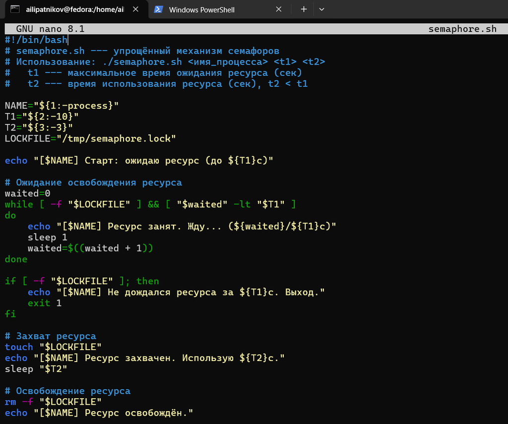

Скрипт semaphore.sh

## Задание 1. Запуск

- **Терминал 1**: `./semaphore.sh proc1 15 5` — на переднем плане
- **Терминал 2**: `./semaphore.sh proc2 15 5 > /dev/pts/N &` — в фоне
- Процессы синхронизируются через `lockfile`

[figure not shown]

Запуск semaphore.sh

## Задание 2. myman.sh — аналог man

- Получает **имя команды** аргументом
- Ищет `/usr/share/man/man1/<команда>.1.gz`
- Распаковывает через `zcat`, рендерит через `groff`, листает через `less`
- Если файла нет — **сообщение об отсутствии**

```bash
zcat "$FILE" | groff -man -Tutf8 | less
```

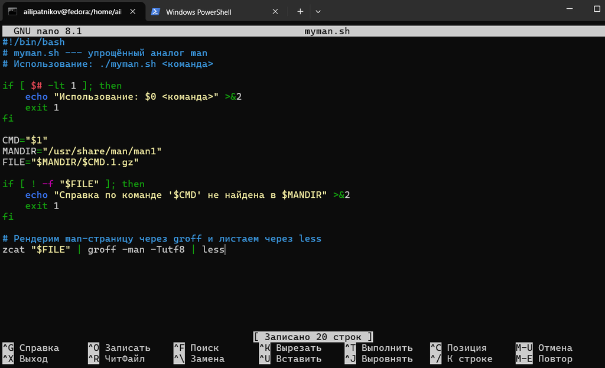

Скрипт myman.sh

## Задание 2. Запуск для ls

[figure not shown]

./myman.sh ls

## Задание 2. Запуск для grep

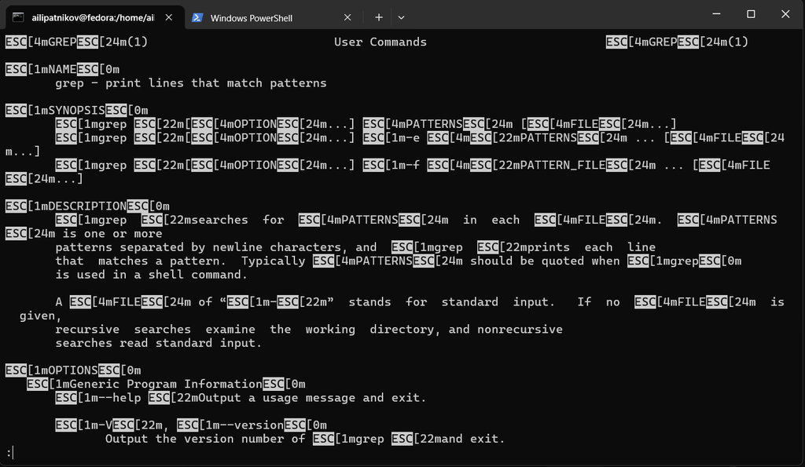

./myman.sh grep

- Аналогично — справка по `grep`

## Задание 2. Сообщение об отсутствии справки

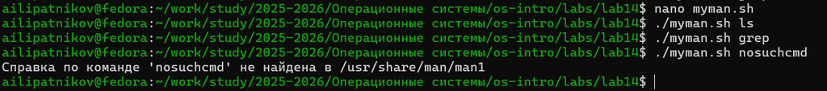

./myman.sh nosuchcmd

- Если файла нет в `/usr/share/man/man1` — **сообщение об ошибке**
- Проверка `[ ! -f "$FILE" ]`

## Задание 3. randletters.sh

- Генерация **случайных букв** `a`–`z` через `$RANDOM`
- `$RANDOM % 26` → число 0–25
- `97 + ...` → код строчной буквы
- Преобразование кода в символ через `printf`

```bash
code=$(( 97 + RANDOM % 26 ))
ch=$(printf "\\$(printf '%03o' "$code")")
```

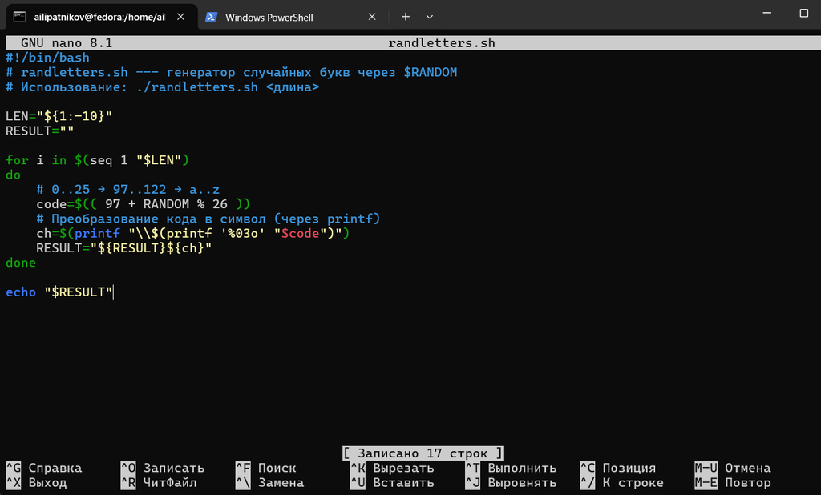

Скрипт randletters.sh

## Задание 3. Запуск

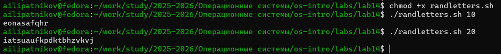

Запуск randletters.sh

# Результаты

## Полученные результаты

Таблица 1: Сводка результатов

[output not shown]

## Ключевые конструкции

Таблица 2: Ключевые конструкции

| Элемент | Пример |
| --- | --- |
| Семафор | `[ -f "$LOCKFILE" ] && sleep 1` |
| Распаковка | `zcat file.1.gz` |
| Рендеринг | `groff -man -Tutf8` |
| Постраничный вывод | `less` |
| Случайное число | `$RANDOM % 26` |
| Код → символ | `printf "\\$(printf '%03o' $code)"` |

# Заключение

## Главный вывод

bash позволяет решать системные задачи без привлечения внешних языков: синхронизировать процессы через семафоры, реализовывать аналоги стандартных утилит (man) и генерировать случайные данные через `$RANDOM`. Навыки применимы при администрировании и автоматизации UNIX-подобных систем.